# Housing prediction

Victory Benjamin

2024-09-26

## loading necessary libraries

- Below i am loading the needed libraries

library(“ggrepel”)

library(corrplot)

library(tidyverse)

library(scales)

library(wesanderson)

library(psych)

library(RColorBrewer)

library(knitr)

library(here)

## loading the train document…

```r
reactable::reactable(train)
```

| Id | MSSubClass | MSZoning | LotFrontage | LotArea | Street | Alley | LotShape | LandContour | Utilities | LotConfig | LandSlope | Neighborhood | Condition1 | Condition2 | BldgType | HouseStyle | OverallQual | OverallCond | YearBuilt | YearRemodAdd | RoofStyle | RoofMatl | Exterior1st | Exterior2nd | MasVnrType | MasVnrArea | ExterQual | ExterCond | Foundation | … |
| --- | --- | --- | --- | --- | --- | --- | --- | --- | --- | --- | --- | --- | --- | --- | --- | --- | --- | --- | --- | --- | --- | --- | --- | --- | --- | --- | --- | --- | --- | --- |
| 1 | 60 | RL | 65 | 8450 | Pave | NA | Reg | Lvl | AllPub | Inside | Gtl | CollgCr | Norm | Norm | 1Fam | 2Story | 7 | 5 | 2003 | 2003 | Gable | CompShg | VinylSd | VinylSd | BrkFace | 196 | Gd | TA | PConc | … |
| 2 | 20 | RL | 80 | 9600 | Pave | NA | Reg | Lvl | AllPub | FR2 | Gtl | Veenker | Feedr | Norm | 1Fam | 1Story | 6 | 8 | 1976 | 1976 | Gable | CompShg | MetalSd | MetalSd | None | 0 | TA | TA | CBlock | … |
| 3 | 60 | RL | 68 | 11250 | Pave | NA | IR1 | Lvl | AllPub | Inside | Gtl | CollgCr | Norm | Norm | 1Fam | 2Story | 7 | 5 | 2001 | 2002 | Gable | CompShg | VinylSd | VinylSd | BrkFace | 162 | Gd | TA | PConc | … |
| 4 | 70 | RL | 60 | 9550 | Pave | NA | IR1 | Lvl | AllPub | Corner | Gtl | Crawfor | Norm | Norm | 1Fam | 2Story | 7 | 5 | 1915 | 1970 | Gable | CompShg | Wd Sdng | Wd Shng | None | 0 | TA | TA | BrkTil | … |
| 5 | 60 | RL | 84 | 14260 | Pave | NA | IR1 | Lvl | AllPub | FR2 | Gtl | NoRidge | Norm | Norm | 1Fam | 2Story | 8 | 5 | 2000 | 2000 | Gable | CompShg | VinylSd | VinylSd | BrkFace | 350 | Gd | TA | PConc | … |
| 6 | 50 | RL | 85 | 14115 | Pave | NA | IR1 | Lvl | AllPub | Inside | Gtl | Mitchel | Norm | Norm | 1Fam | 1.5Fin | 5 | 5 | 1993 | 1995 | Gable | CompShg | VinylSd | VinylSd | None | 0 | TA | TA | Wood | … |
| 7 | 20 | RL | 75 | 10084 | Pave | NA | Reg | Lvl | AllPub | Inside | Gtl | Somerst | Norm | Norm | 1Fam | 1Story | 8 | 5 | 2004 | 2005 | Gable | CompShg | VinylSd | VinylSd | Stone | 186 | Gd | TA | PConc | … |
| 8 | 60 | RL | NA | 10382 | Pave | NA | IR1 | Lvl | AllPub | Corner | Gtl | NWAmes | PosN | Norm | 1Fam | 2Story | 7 | 6 | 1973 | 1973 | Gable | CompShg | HdBoard | HdBoard | Stone | 240 | TA | TA | CBlock | … |
| 9 | 50 | RM | 51 | 6120 | Pave | NA | Reg | Lvl | AllPub | Inside | Gtl | OldTown | Artery | Norm | 1Fam | 1.5Fin | 7 | 5 | 1931 | 1950 | Gable | CompShg | BrkFace | Wd Shng | None | 0 | TA | TA | BrkTil | … |
| 10 | 190 | RL | 50 | 7420 | Pave | NA | Reg | Lvl | AllPub | Corner | Gtl | BrkSide | Artery | Artery | 2fmCon | 1.5Unf | 5 | 6 | 1939 | 1950 | Gable | CompShg | MetalSd | MetalSd | None | 0 | TA | TA | BrkTil | … |

[output cut: 1450 more lines]

## view the structure of the data

```r
str(head(train, 10))
```

```
## tibble [10 × 81] (S3: tbl_df/tbl/data.frame)
##  $ Id           : num [1:10] 1 2 3 4 5 6 7 8 9 10
##  $ MSSubClass   : num [1:10] 60 20 60 70 60 50 20 60 50 190
##  $ MSZoning     : chr [1:10] "RL" "RL" "RL" "RL" ...
##  $ LotFrontage  : num [1:10] 65 80 68 60 84 85 75 NA 51 50
##  $ LotArea      : num [1:10] 8450 9600 11250 9550 14260 ...
##  $ Street       : chr [1:10] "Pave" "Pave" "Pave" "Pave" ...
##  $ Alley        : chr [1:10] NA NA NA NA ...
##  $ LotShape     : chr [1:10] "Reg" "Reg" "IR1" "IR1" ...
##  $ LandContour  : chr [1:10] "Lvl" "Lvl" "Lvl" "Lvl" ...
##  $ Utilities    : chr [1:10] "AllPub" "AllPub" "AllPub" "AllPub" ...
##  $ LotConfig    : chr [1:10] "Inside" "FR2" "Inside" "Corner" ...
##  $ LandSlope    : chr [1:10] "Gtl" "Gtl" "Gtl" "Gtl" ...
##  $ Neighborhood : chr [1:10] "CollgCr" "Veenker" "CollgCr" "Crawfor" ...
##  $ Condition1   : chr [1:10] "Norm" "Feedr" "Norm" "Norm" ...
```

[output cut: 67 more lines]

```r
test_label <- train$Id
train$Id <- NULL
test$Id <- NULL
all <- bind_rows(train, test)
dim(all)
```

```
## [1] 2919   80
```

### Exploring some of the most important variables

#### 1. The response variable; SalePrice

##### As you can see, the sale prices are right skewed. This was expected as few people can afford very expensive houses. I will keep this in mind, and take measures before modeling.

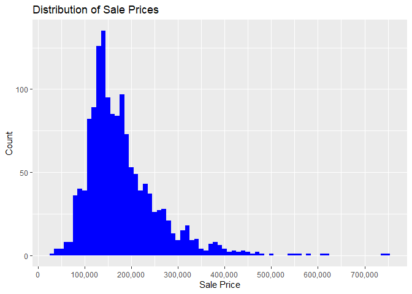

```r
ggplot(data= all[!is.na(all$SalePrice), ], aes(x = SalePrice))+
  geom_histogram(fill= "blue", binwidth = 10000)+
  scale_x_continuous(breaks = seq(0,800000, by= 100000), labels = comma)+
  labs(title = "Distribution of Sale Prices",
       x = "Sale Price",
       y = "Count")
```

#### The most important numeric predictors

##### The character variables need some work before I can use them. To get a feel for the dataset, I decided to first see which numeric variables have a high correlation with the SalePrice.

```r
numericVars <- all%>%
  select(where(is.numeric))


cat("there are", length(numericVars), "numeric variables")
```

```
## there are 37 numeric variables
```

```r
cor_numVar <- numericVars %>%
  cor(use = "pairwise.complete.obs", method = "pearson") #correlations of all numeric variables



#sort on decreasing correlations with SalePrice
cor_sorted <- cor_numVar[ "SalePrice", ] %>%
  .[abs(.) > 0.5]  %>%
  sort( decreasing=TRUE)


# call names() on the sorted corr. matrix to get a vector of names that i can use to subset the corr. matrix
CorHigh <- names(cor_sorted)
CorHigh
```

```
##  [1] "SalePrice"    "OverallQual"  "GrLivArea"    "GarageCars"   "GarageArea"
##  [6] "TotalBsmtSF"  "1stFlrSF"     "FullBath"     "TotRmsAbvGrd" "YearBuilt"
## [11] "YearRemodAdd"
```

```r
#subset the correlation matrix
cor_numVar <- cor_numVar[CorHigh, CorHigh]
cor_numVar
```

```
##              SalePrice OverallQual GrLivArea GarageCars GarageArea TotalBsmtSF
## SalePrice    1.0000000   0.7909816 0.7086245  0.6404092  0.6234314   0.6135806
## OverallQual  0.7909816   1.0000000 0.5751261  0.6007437  0.5651223   0.5492937
## GrLivArea    0.7086245   0.5751261 1.0000000  0.4899330  0.4854687   0.4452760
## GarageCars   0.6404092   0.6007437 0.4899330  1.0000000  0.8897004   0.4379966
## GarageArea   0.6234314   0.5651223 0.4854687  0.8897004  1.0000000   0.4860666
## TotalBsmtSF  0.6135806   0.5492937 0.4452760  0.4379966  0.4860666   1.0000000
## 1stFlrSF     0.6058522   0.4791519 0.5625383  0.4405401  0.4920112   0.8016700
## FullBath     0.5606638   0.5284826 0.6302857  0.4799882  0.4084869   0.3277620
## TotRmsAbvGrd 0.5337232   0.3897614 0.8083544  0.3580533  0.3286871   0.2821258
## YearBuilt    0.5228973   0.5975541 0.2426659  0.5380737  0.4807350   0.4085145
## YearRemodAdd 0.5071010   0.5715323 0.3169720  0.4260217  0.3767654   0.2981066
##               1stFlrSF  FullBath TotRmsAbvGrd YearBuilt YearRemodAdd
## SalePrice    0.6058522 0.5606638    0.5337232 0.5228973    0.5071010
## OverallQual  0.4791519 0.5284826    0.3897614 0.5975541    0.5715323
## GrLivArea    0.5625383 0.6302857    0.8083544 0.2426659    0.3169720
## GarageCars   0.4405401 0.4799882    0.3580533 0.5380737    0.4260217
## GarageArea   0.4920112 0.4084869    0.3286871 0.4807350    0.3767654
## TotalBsmtSF  0.8016700 0.3277620    0.2821258 0.4085145    0.2981066
## 1stFlrSF     1.0000000 0.3730769    0.3917824 0.3108136    0.2422452
## FullBath     0.3730769 1.0000000    0.5273370 0.4711689    0.4579799
## TotRmsAbvGrd 0.3917824 0.5273370    1.0000000 0.1142804    0.1982496
## YearBuilt    0.3108136 0.4711689    0.1142804 1.0000000    0.6122346
## YearRemodAdd 0.2422452 0.4579799    0.1982496 0.6122346    1.0000000
```

#### The correlation graph

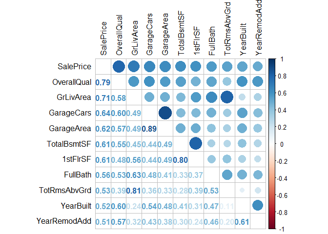

```r
corrplot.mixed(cor_numVar, tl.col="black", tl.pos = "lt")
```

#### Overall Quality

##### Overall Quality has the highest correlation with SalePrice among the numeric variables (0.79). It rates the overall material and finish of the house on a scale from 1 (very poor) to 10 (very excellent).

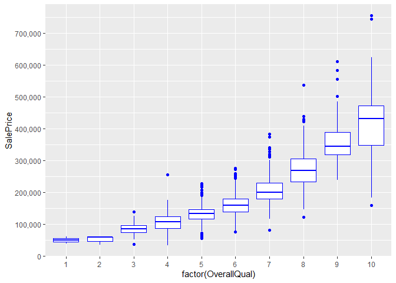

```r
ggplot(data = all[!is.na(all$SalePrice), ],
       aes(x= factor(OverallQual), y= SalePrice))+
  geom_boxplot(colour= "blue")+
  scale_y_continuous(breaks= seq(0, 800000, 100000), labels = comma)
```

#### Above Grade (Ground) Living Area (square feet)

##### The numeric variable with the second highest correlation with SalesPrice is the Above Grade Living Area. This make a lot of sense; big houses are generally more expensive.

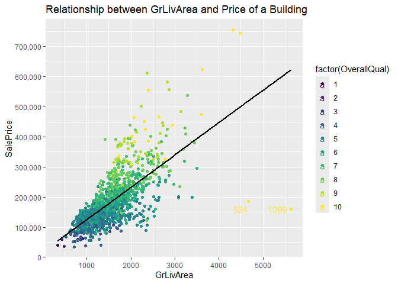

```r
ggplot(data = all[!is.na(all$SalePrice), ],
         aes(x = GrLivArea, y = SalePrice, colour = factor(OverallQual))) +

    geom_point() +

    geom_smooth(method = "lm", se = FALSE, colour = "black", aes(group = 1)) +

    scale_y_continuous(breaks = seq(0, 800000, 100000), labels = comma) +

    labs(title = "Relationship between GrLivArea and Price of a Building") +

    geom_text_repel(aes(label = ifelse(GrLivArea > 4500, rownames(all), ""))) +

    scale_colour_viridis_d()
```

##### the two houses with really big living areas and low SalePrices seem outliers (houses 524 and 1299, see labels in graph). I will not take them out yet, as taking outliers can be dangerous. For instance, a low score on the Overall Quality could explain a low price. However, as you can see below, these two houses actually also score maximum points on Overall Quality. Therefore, I will keep houses 1299 and 524 in mind as prime candidates to take out as outliers.

#### HANDLING MISSING VALUES,GROUPING RELATED VARIABLES, CONVERTING CLEAR ORDINAL VALUES TO ORDINAL NUMERIC VALUES, AND CONVERTING NON-ORDINAL VALUES TO FACTORS

##### pool variables

```r
all%>%
  mutate(PoolQC = ifelse(is.na(PoolQC), "none",PoolQC))
```

```
## # A tibble: 2,919 × 80
##    MSSubClass MSZoning LotFrontage LotArea Street Alley LotShape LandContour
##         <dbl> <chr>          <dbl>   <dbl> <chr>  <chr> <chr>    <chr>
##  1         60 RL                65    8450 Pave   <NA>  Reg      Lvl
##  2         20 RL                80    9600 Pave   <NA>  Reg      Lvl
##  3         60 RL                68   11250 Pave   <NA>  IR1      Lvl
##  4         70 RL                60    9550 Pave   <NA>  IR1      Lvl
##  5         60 RL                84   14260 Pave   <NA>  IR1      Lvl
##  6         50 RL                85   14115 Pave   <NA>  IR1      Lvl
##  7         20 RL                75   10084 Pave   <NA>  Reg      Lvl
##  8         60 RL                NA   10382 Pave   <NA>  IR1      Lvl
##  9         50 RM                51    6120 Pave   <NA>  Reg      Lvl
## 10        190 RL                50    7420 Pave   <NA>  Reg      Lvl
## # ℹ 2,909 more rows
## # ℹ 72 more variables: Utilities <chr>, LotConfig <chr>, LandSlope <chr>,
## #   Neighborhood <chr>, Condition1 <chr>, Condition2 <chr>, BldgType <chr>,
## #   HouseStyle <chr>, OverallQual <dbl>, OverallCond <dbl>, YearBuilt <dbl>,
## #   YearRemodAdd <dbl>, RoofStyle <chr>, RoofMatl <chr>, Exterior1st <chr>,
## #   Exterior2nd <chr>, MasVnrType <chr>, MasVnrArea <dbl>, ExterQual <chr>,
## #   ExterCond <chr>, Foundation <chr>, BsmtQual <chr>, BsmtCond <chr>, …
```

```r
qualities <- c("none"= 0, "Po" = 1,  "Fa"= 2, "TA"= 3, "Gd" = 4, "Ex" = 5)

all <- all %>%
  mutate(PoolQC = recode(PoolQC, !!!qualities))

all <- all %>%
  mutate(PoolQC = as.numeric(PoolQC))

pool_variable <-  all %>%
  filter(if_all(c(contains("Pool"),OverallQual), ~ !is.na(.)))%>%
  filter(PoolArea > 0) %>%
  select(contains("Pool"),OverallQual)

pool_variable
```

```
## # A tibble: 10 × 3
##    PoolArea PoolQC OverallQual
##       <dbl>  <dbl>       <dbl>
##  1      512      5           8
##  2      648      2           6
##  3      576      4           6
##  4      555      5          10
##  5      480      4          10
##  6      519      2           7
##  7      738      4           6
##  8      144      5          10
##  9      228      5           8
## 10      800      4           7
```

```r
table(all$PoolArea)
```

```
##
##    0  144  228  368  444  480  512  519  555  561  576  648  738  800
## 2906    1    1    1    1    1    1    1    1    1    1    1    1    1
```

```r
table(all$PoolQC)
```

```
##
## 2 4 5
## 2 4 4
```

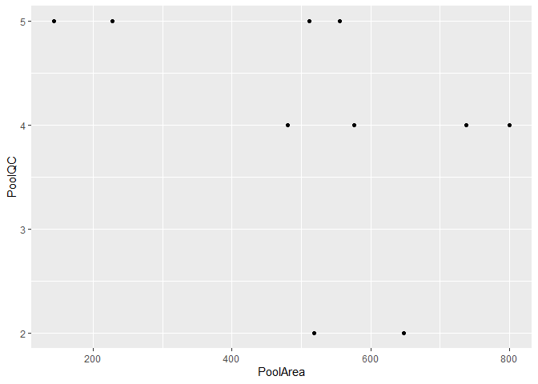

```r
ggplot(data = pool_variable, aes(y= PoolQC, x= PoolArea))+
   geom_point()
```

```r
cor_pool <- pool_variable %>%
cor(use = "pairwise.complete.obs", method = "spearman")
cor_pool
```

```
##               PoolArea     PoolQC OverallQual
## PoolArea     1.0000000 -0.5449493  -0.7253543
## PoolQC      -0.5449493  1.0000000   0.6626559
## OverallQual -0.7253543  0.6626559   1.0000000
```

```r
mcar_poolqc <- pool_variable %>%
  filter(PoolArea >0, PoolQC == 0)
mcar_poolqc
```

```
## # A tibble: 0 × 3
## # ℹ 3 variables: PoolArea <dbl>, PoolQC <dbl>, OverallQual <dbl>
```

##### filling MCAR poolQC with the overall quality for that variable

```r
pool_variable <- pool_variable %>%
  mutate(PoolQC = ifelse(PoolArea >0 & PoolQC == 0,round(OverallQual/2),PoolQC ))
pool_variable
```

```
## # A tibble: 10 × 3
##    PoolArea PoolQC OverallQual
##       <dbl>  <dbl>       <dbl>
##  1      512      5           8
##  2      648      2           6
##  3      576      4           6
##  4      555      5          10
##  5      480      4          10
##  6      519      2           7
##  7      738      4           6
##  8      144      5          10
##  9      228      5           8
## 10      800      4           7
```